# Between Sample (Beta) Diversity of Microbes according to Rootstock Genotype

Julie Cardon

2024-04-26

# Goals

1. Load in phyloseq data with rooted tree.
2. Evaluate sequencing depth and remove samples.
3. Normalize the read counts between samples.
4. Calculate community dissimilarities. Numbers between 0 and 1. If 0, completely similar versus if they are 1, then they’re completely dissimilar.
   1. **Sorensen**: Shared Species as a binary value: Abundance-unweighted
   2. **Bray-Curtis**: Shared Abundant species: Abundance-weighted
   3. **(Abundance-)Weighted UNIFRAC**: Consider Abundant Species and where they fall on the tree
5. Visualize the community data with two unconstrained Ordinations:
   1. **PCoA**: Linear Method. Eigenvalue = how much variation is explained by each axis. Choose to view axis 1, 2, 3, etc. and plot them together.
   2. **NMDS**: Non-linear. Smush multiple Dimensions into 2 or 3 axes. Need to report Stress value (ideally <0.15).
6. Run statistics with PERMANOVA and betadispR.

# Setup

## Set the seed

```r
# Any number can be chosen
set.seed(238428)
```

## Load Libraries

```r
#install.packages("vegan")
pacman::p_load(tidyverse, devtools, phyloseq, patchwork, vegan,
               install = FALSE)
# To add some statistical comparison, we need to load a couple of packages:
#install.packages("ggpubr")
#library(ggpubr)
#install.packages("rstatix")
#library(rstatix)

# Load colors for Rootstocks
Rootstock_colors <- c(
  "Bud9" = "indianred",
  "Bud10" = "burlywood3",
  "G11" = "#D9CC3C",
  "G41" = "#A0E0BA",
  "G202" = "#00ADA7",
  "G213" = "dodgerblue4",
  "G890" = "khaki4",
  "G935" = "honeydew3",
  "G969" = "brown",
  "M7" = "palegreen4",
  "M9337" = "gold",
  "M9Nic29" = "dodgerblue3",
  "M9pajam2" = "peru",
  "V1" = "plum4",
  "G210" = "paleturquoise3",
  "Soil" = "palevioletred")
```

## Load Data

```r
# Load in rooted phylogenetic tree!
load("data/03_Phylogenetic_Tree/phytree_preprocessed_physeq.RData")
midroot_physeq_rm_susASVs
```

```
## phyloseq-class experiment-level object
## otu_table()   OTU Table:         [ 64989 taxa and 168 samples ]
## sample_data() Sample Data:       [ 168 samples by 14 sample variables ]
## tax_table()   Taxonomy Table:    [ 64989 taxa by 9 taxonomic ranks ]
## phy_tree()    Phylogenetic Tree: [ 64989 tips and 64988 internal nodes ]
```

```r
unrooted_physeq_rm_sus_ASVs
```

```
## phyloseq-class experiment-level object
## otu_table()   OTU Table:         [ 64989 taxa and 168 samples ]
## sample_data() Sample Data:       [ 168 samples by 14 sample variables ]
## tax_table()   Taxonomy Table:    [ 64989 taxa by 9 taxonomic ranks ]
## phy_tree()    Phylogenetic Tree: [ 64989 tips and 64987 internal nodes ]
```

# Explore Read Counts

## Raw read depth

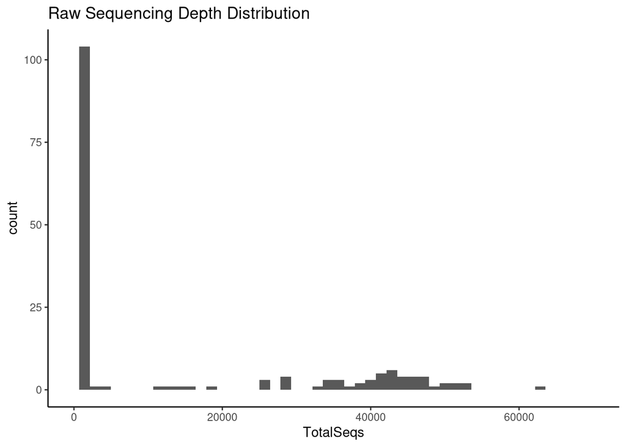

```r
# Calculate the total number of reads per sample.
raw_TotalSeqs_df  <-
  midroot_physeq_rm_susASVs %>%
  # calculate the sample read sums
  sample_sums() %>%
  data.frame()
# name the column
colnames(raw_TotalSeqs_df)[1] <- "TotalSeqs"

#View(raw_TotalSeqs_df)

# make histogram of raw reads
raw_TotalSeqs_df %>%
  ggplot(aes(x = TotalSeqs)) +
  geom_histogram(bins = 50) +
  scale_x_continuous(limits = c(0, 70000)) +
  labs(title = "Raw Sequencing Depth Distribution") +
  theme_classic()
```

## Remove lowly seq sample

```r
raw_rooted_physeq <-
  midroot_physeq_rm_susASVs %>%
  # remove lowly seq sample that was outlier in alpha diversity analysis
  subset_samples(Sample != "G11_2022") %>%
  # any asvs unique to this sample will also be removed
  prune_taxa(taxa_sums(.) > 0, .)

# Inspect
raw_rooted_physeq
```

```
## phyloseq-class experiment-level object
## otu_table()   OTU Table:         [ 64983 taxa and 167 samples ]
## sample_data() Sample Data:       [ 167 samples by 14 sample variables ]
## tax_table()   Taxonomy Table:    [ 64983 taxa by 9 taxonomic ranks ]
## phy_tree()    Phylogenetic Tree: [ 64983 tips and 64982 internal nodes ]
```

```r
# what is the minimum number of sequences
raw_rooted_physeq %>%
  sample_sums() %>%
  min()
```

```
## [1] 572
```

## Normalize read counts

```r
### scale_reads function
####################################################################################
# Function to scale reads: http://deneflab.github.io/MicrobeMiseq/
# Scales reads by
# 1) taking proportions
# 2) multiplying by a given library size of n
# 3) rounding
# Default for n is the minimum sample size in your library
# Default for round is floor

matround <- function(x){trunc(x+0.5)}

scale_reads <- function(physeq, n = min(sample_sums(physeq)), round = "round") {

  # transform counts to n
  physeq.scale <- transform_sample_counts(physeq, function(x) {(n * x/sum(x))})

  # Pick the rounding functions
  if (round == "floor"){
    otu_table(physeq.scale) <- floor(otu_table(physeq.scale))
  } else if (round == "round"){
    otu_table(physeq.scale) <- round(otu_table(physeq.scale))
  } else if (round == "matround"){
    otu_table(physeq.scale) <- matround(otu_table(physeq.scale))
  }

  # Prune taxa and return new phyloseq object
  physeq.scale <- prune_taxa(taxa_sums(physeq.scale) > 0, physeq.scale)
  return(physeq.scale)
}
```

## Scale the reads and check the distribution of the seq depth

This is where one might decide use rarefaction to normalize data.

```r
min(sample_sums(raw_rooted_physeq))
```

```
## [1] 572
```

```r
# Scale reads by the above function
scaled_rooted_physeq <-
  raw_rooted_physeq %>%
  scale_reads(round = "matround")

# Calculate the read depth
scaled_TotalSeqs_df <-
  scaled_rooted_physeq %>%
  sample_sums() %>%
  data.frame()
colnames(scaled_TotalSeqs_df)[1] <-"TotalSeqs"

# Inspect
head(scaled_TotalSeqs_df)
```

```
##          TotalSeqs
## B4_2022        367
## G2_2022        441
## G10_2022       457
## G18_2022       347
## G26_2022       322
## G34_2022       413
```

```r
# Check the range of the data
min_seqs <- min(scaled_TotalSeqs_df$TotalSeqs); min_seqs
```

```
## [1] 306
```

```r
max_seqs <- max(scaled_TotalSeqs_df$TotalSeqs); max_seqs
```

```
## [1] 612
```

```r
# range
max_seqs - min_seqs
```

```
## [1] 306
```

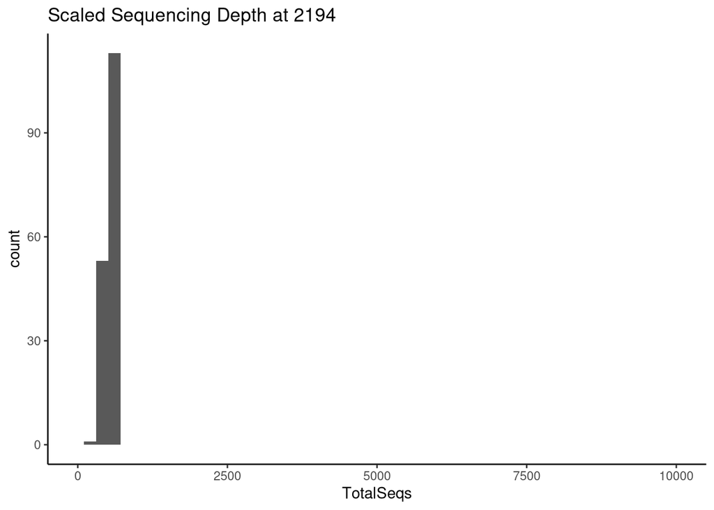

```r
# Plot Histogram
scaled_TotalSeqs_df %>%
  ggplot(aes(x = TotalSeqs)) +
  geom_histogram(bins = 50) +
  scale_x_continuous(limits = c(0, 10000)) +
  labs(title = "Scaled Sequencing Depth at 2194") +
  theme_classic()
```

# Cacluate & Visualize community dissimilarity

Exploratory analyses from Paliy & Shankar (2016) paper, which is using unconstrained ordination methods like PCoA.

## PCoA

### Sorensen

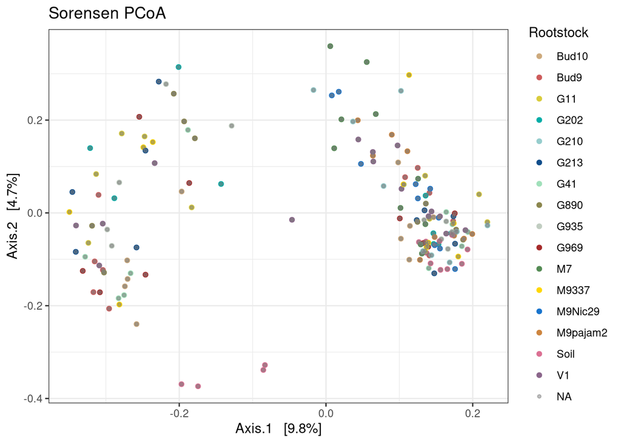

```r
# Calculate sorensen dissimilarity: Abundance-unweighted of shared taxa
scaled_soren_pcoa <-
  ordinate(
    physeq = scaled_rooted_physeq,
    method = "PCoA",
    distance = "bray", binary = TRUE)

#str(scaled_soren_pcoa)
# Plot the ordination
soren_rootstock_pcoa <- plot_ordination(
  physeq = scaled_rooted_physeq,
  ordination = scaled_soren_pcoa,
  color = "Rootstock",
  #shape = "Rootstock",
  title = "Sorensen PCoA") +
  geom_point(size=1, alpha = 0.5, aes(color = ARD)) +
  #scale_shape_manual(values = c(15,16,17,18, 19, 20)) +
  scale_color_manual(values = Rootstock_colors) +
  theme_bw()
# Show the plot
soren_rootstock_pcoa
```

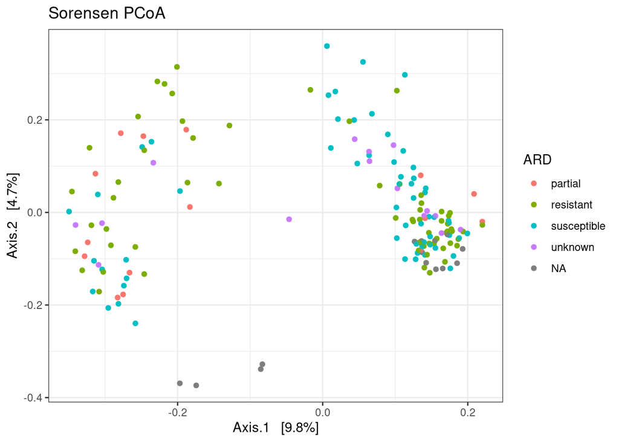

```r
# Make a Pcoa based on ARD status
soren_ARD_pcoa <- plot_ordination(
  physeq = scaled_rooted_physeq,
  ordination = scaled_soren_pcoa,
  color = "ARD",
  #shape = "Rootstock",
  title = "Sorensen PCoA") +
  geom_point(size=1, alpha = 0.5, aes(color = ARD)) +
  #scale_shape_manual(values = c(15,16,17,18, 19, 20)) +
  #scale_color_manual(values = Rootstock_colors) +
  theme_bw()
# Show the plot
soren_ARD_pcoa
```

*Note that I have removed the PERMANOVA test to below the ordinations. We will come back to it later!*

Here, we are evaluating the shared taxa by presence/absence (abundance-unweighted) in the Sorensen metric.

Note that there is a weird arch or horseshoe-effect in the data. This is likely because we have complete species turnover between our stations. If you have this in your data, please take a look at the paper by [Morton et al., 2017](https://journals.asm.org/doi/10.1128/msystems.00166-16). More on this in NMDS…

Note that:

- Axis 1 = ~9.8% of variation
- Axis 2 = ~4.7% of variation

This means we explain 14.5% of the variation in the data in these two axes.

### Bray

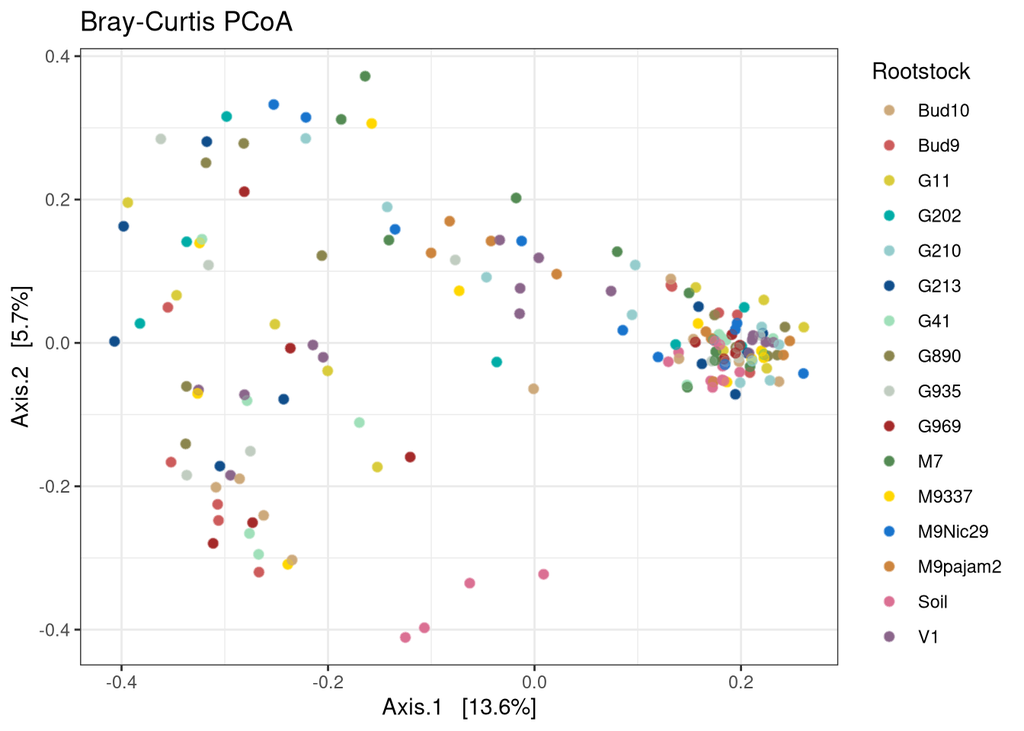

```r
# Calculate the BC distance
scaled_BC_pcoa <-
  ordinate(
    physeq = scaled_rooted_physeq,
    method = "PCoA",
    distance = "bray")

# Plot the PCoA
bray_rootstock_pcoa <-
  plot_ordination(
    physeq = scaled_rooted_physeq,
    ordination = scaled_BC_pcoa,
    color = "Rootstock",
    #shape = "Rootstock",
    title = "Bray-Curtis PCoA") +
  geom_point(size=2, alpha = 0.5, aes(color = Rootstock)) +
  #scale_shape_manual(values = c(15,16,17,18, 19, 20)) +
  scale_color_manual(values = c(Rootstock_colors)) +
  theme_bw()
bray_rootstock_pcoa
```

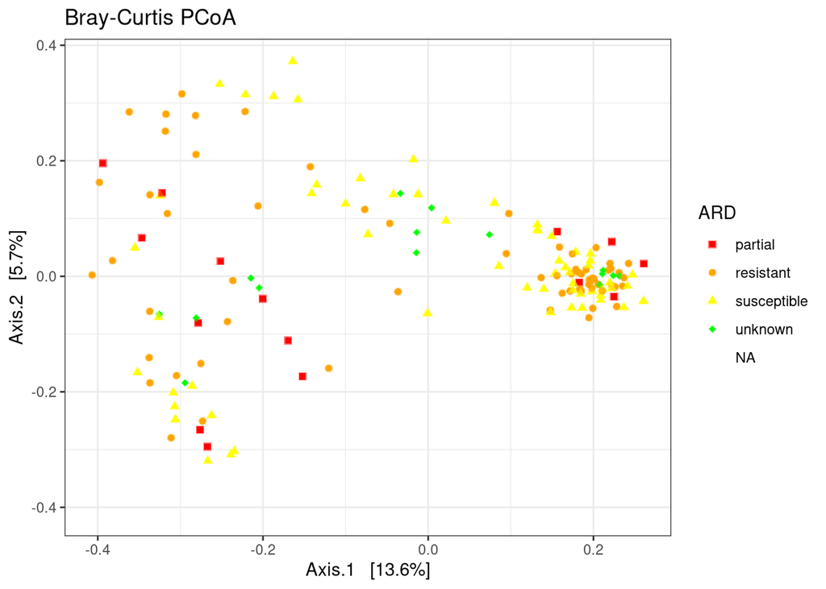

```r
# For ARD resistance
# Plot the PCoA
bray_ARD_pcoa <-
  plot_ordination(
    physeq = scaled_rooted_physeq,
    ordination = scaled_BC_pcoa,
    color = "ARD",
    shape = "ARD",
    title = "Bray-Curtis PCoA") +
  geom_point(size=2, alpha = 0.5, aes(color = ARD)) +
  scale_shape_manual(values = c(15,16,17,18, 19, 20)) +
  scale_color_manual(values = c("red", "orange", "yellow", "green", "blue")) +
  theme_bw()
bray_ARD_pcoa
```

Here, we are evaluating the shared taxa and then weighting them by their abundances, which provides more influence for species that are more abundant.

Note that there is a weird arch or horseshoe-effect in the data. This is likely because we have complete species turnover between our stations. If you have this in your data, please take a look at the paper by [Morton et al., 2017](https://journals.asm.org/doi/10.1128/msystems.00166-16). More on this in NMDS…

Note that:

- Axis 1 = ~13.6% of variation
- Axis 2 = ~5.7% of variation

This means we explain 19.3% of the variation in the data in these two axes, which is more than the previous plot with the Sorensen Dissimilarity. Abundance does seem to have an influence!!

Samples do not separate very well by rootstock. The results are similar if I plot using ARD resistance as the variable. There is a cluster of points on the right-hand side in all of the plots; I think this maybe be the 2023 data cluster together differently from the 2022 data.

### Weighted Unifrac

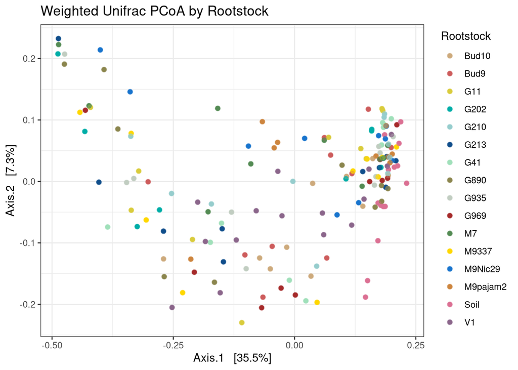

```r
# Calculate the BC distance
scaled_wUNI_pcoa <-
  ordinate(
    physeq = scaled_rooted_physeq,
    method = "PCoA",
    distance = "wunifrac")

# Plot the PCoA
wUNI_rootstock_pcoa <-
  plot_ordination(
    physeq = scaled_rooted_physeq,
    ordination = scaled_wUNI_pcoa,
    color = "Rootstock",
    #shape = "Rootstock",
    title = "Weighted Unifrac PCoA by Rootstock") +
  geom_point(size=2, alpha = 0.5, aes(color = Rootstock)) +
  #scale_shape_manual(values = c(15,16,17,18, 19, 20)) +
  scale_color_manual(values = c(Rootstock_colors)) +
  theme_bw()
wUNI_rootstock_pcoa
```

Here, we are evaluating the shared taxa and then weighting them by their abundances, which provides more influence for species that are more abundant.

Note that there is a slight arch or horseshoe-effect in the data. This is likely because we have complete species turnover between our stations. If you have this in your data, please take a look at the paper by [Morton et al., 2017](https://journals.asm.org/doi/10.1128/msystems.00166-16). More on this in NMDS…

Note that:

- Axis 1 = ~35.5% of variation
- Axis 2 = ~7.3% of variation

This means we explain *42.8*% of the variation in the data in these two axes (!!!), which is significantly more than the previous plots with the taxonomic dissimilarity measures. Here, phylogeny seems to be very important! This means that taxa that are abundant are found in different places in the phylogenetic tree. Therefore, the evoultionary distances (aka the branch lengths) and their abundances seem to have a major influence!!

It doesn’t really look like the samples are separating more within each group than they did with Sorensen.

## Combine PCoAs

Let’s plot all three together into one plot to have a concise visualization of the three metrics.

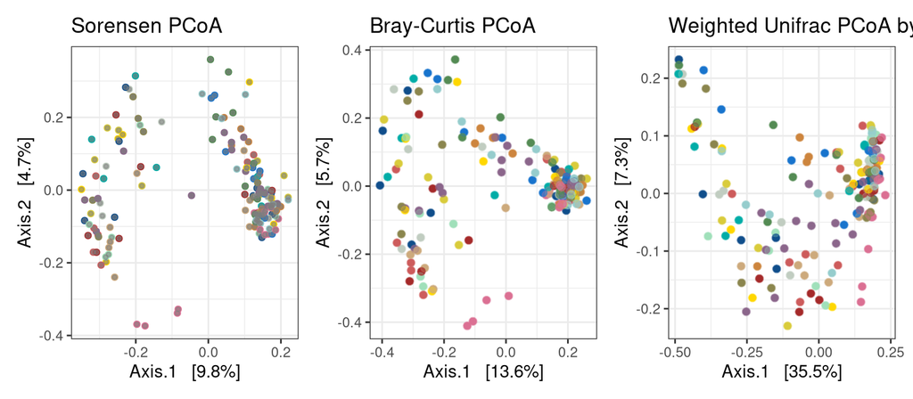

```r
(soren_rootstock_pcoa + theme(legend.position = "none")) +
  (bray_rootstock_pcoa + theme(legend.position = "none")) +
    (wUNI_rootstock_pcoa + theme(legend.position = "none"))
```

## NMDS

### Weighted Unifrac

Since we did 3 of the dissimilarity metrics for the PCoA, let’s just plot one example of them for the NMDS plotting. Here, we will use weighted Unifrac

```r
# Calculate the Weighted Unifrac distance
scaled_wUNI_nmds <-
  ordinate(
    physeq = scaled_rooted_physeq,
    method = "NMDS",
    distance = "wunifrac")
```

```
## *** Best solution was not repeated -- monoMDS stopping criteria:
##      5: no. of iterations >= maxit
##     15: stress ratio > sratmax
```

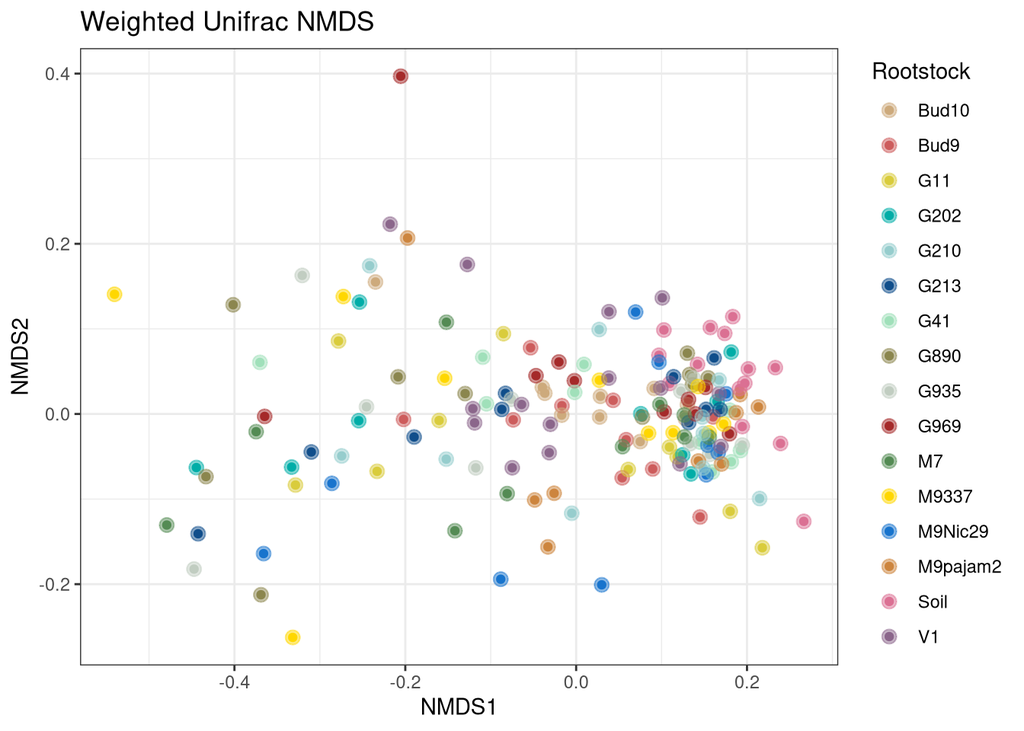

```r
# Plot the PCoA
wUNI_rootstock_nmds <-
  plot_ordination(
    physeq = scaled_rooted_physeq,
    ordination = scaled_wUNI_nmds,
    color = "Rootstock",
    #shape = "ARD",
    title = "Weighted Unifrac NMDS") +
  geom_point(size=3, alpha = 0.5, aes(color = Rootstock)) +
  #scale_shape_manual(values = c(15,16,17,18, 19, 20)) +
  scale_color_manual(values = c(Rootstock_colors)) +
  theme_bw()
wUNI_rootstock_nmds
```

I don’t see a stress value for this plot. And, It seems important to emphasize that the PCoA and the NMDS plot both look pretty similar!

In this case, I would always prefer to report the PCoA results because they are linear and provide a lot more post-hoc analyses to follow up with. In addition, it’s helpful to only have 2 axes of variation and show how much variation is explained.

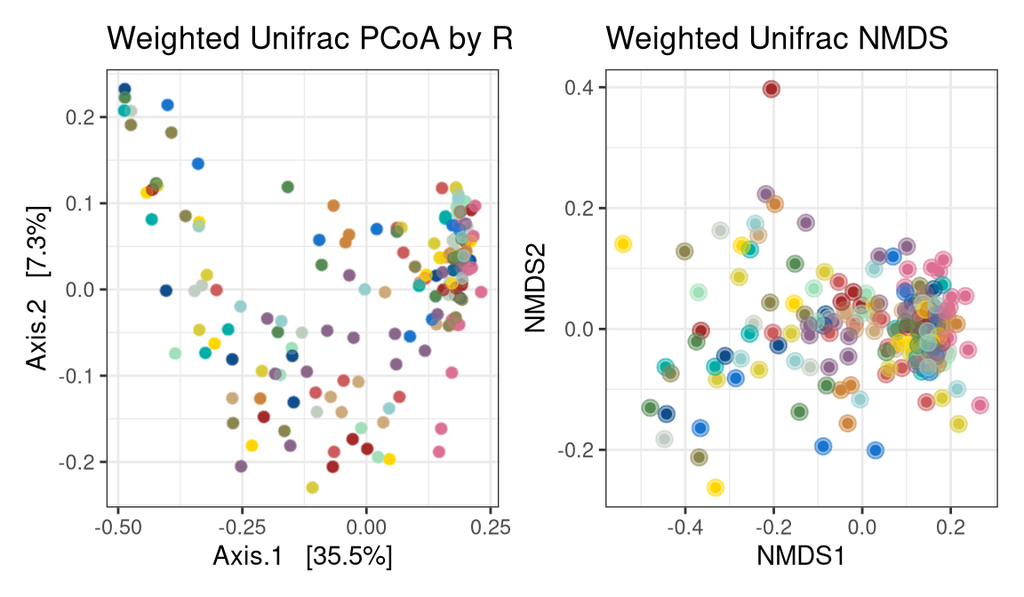

```r
(wUNI_rootstock_pcoa + theme(legend.position = "none")) +
  (wUNI_rootstock_nmds + theme(legend.position = "none"))
```

# Statistical Significance Testing

## PERMANOVA

```r
# Calculate all three of the distance matrices
scaled_sorensen_dist <- phyloseq::distance(scaled_rooted_physeq, method = "bray", binary = TRUE)
scaled_bray_dist <- phyloseq::distance(scaled_rooted_physeq, method = "bray")
scaled_wUnifrac_dist <- phyloseq::distance(scaled_rooted_physeq, method = "wunifrac")

# make a data frame from the sample_data
# All distance matrices will be the same metadata because they
# originate from the same phyloseq object.
metadata <- data.frame(sample_data(scaled_rooted_physeq))

# Adonis test
# In this example we are testing the hypothesis that the fifteen rootstocks
# that were collected have different centroids in the ordination space
# for each of the dissimilarity metrics, we are using a discrete variable
adonis2(scaled_sorensen_dist ~ Rootstock, data = metadata)
```

```
## Permutation test for adonis under reduced model
## Terms added sequentially (first to last)
## Permutation: free
## Number of permutations: 999
##
## adonis2(formula = scaled_sorensen_dist ~ Rootstock, data = metadata)
##            Df SumOfSqs      R2     F Pr(>F)
## Rootstock  15    6.702 0.10714 1.208  0.001 ***
## Residual  151   55.854 0.89286
## Total     166   62.557 1.00000
## ---
## Signif. codes:  0 '***' 0.001 '**' 0.01 '*' 0.05 '.' 0.1 ' ' 1
```

```r
adonis2(scaled_bray_dist ~ Rootstock, data = metadata)
```

```
## Permutation test for adonis under reduced model
## Terms added sequentially (first to last)
## Permutation: free
## Number of permutations: 999
##
## adonis2(formula = scaled_bray_dist ~ Rootstock, data = metadata)
##            Df SumOfSqs      R2     F Pr(>F)
## Rootstock  15    6.354 0.10959 1.239  0.002 **
## Residual  151   51.626 0.89041
## Total     166   57.980 1.00000
## ---
## Signif. codes:  0 '***' 0.001 '**' 0.01 '*' 0.05 '.' 0.1 ' ' 1
```

```r
adonis2(scaled_wUnifrac_dist ~ Rootstock, data = metadata)
```

```
## Permutation test for adonis under reduced model
## Terms added sequentially (first to last)
## Permutation: free
## Number of permutations: 999
##
## adonis2(formula = scaled_wUnifrac_dist ~ Rootstock, data = metadata)
##            Df SumOfSqs      R2      F Pr(>F)
## Rootstock  15    2.574 0.11965 1.3681  0.014 *
## Residual  151   18.939 0.88035
## Total     166   21.513 1.00000
## ---
## Signif. codes:  0 '***' 0.001 '**' 0.01 '*' 0.05 '.' 0.1 ' ' 1
```

Note that:

- R2 = the percent variation explained = 11%
- F = the F-Statistic, which represents the importance value.=1.2
- Pr(>F) = the pvalue =0.001

These numbers were the same for essentially all 3 measures, slightly higher for Unifrac, which explains ~12% of the variation in the data and also has the highest F-statistic (and highest p-value, 0.014).

## I won’t do a multivariable permanova for now.

```r
# We might also care about other variables
# Here, we will add date and fraction as variables
# multiplicative model ORDER MATTERS!
#adonis2(scaled_sorensen_dist ~ Rootstock * ARD * SequencingRun, data = metadata)
#adonis2(scaled_bray_dist ~ Rootstock * ARD * SequencingRun, data = metadata)
# Note that the ORDER MATTERS!
#adonis2(scaled_wUnifrac_dist ~ Rootstock * ARD * SequencingRun, data = metadata)
#adonis2(scaled_wUnifrac_dist ~ SequencingRun * ARD * Rootstock, data = metadata)
#NAs are showing as missing data (if want to find out where the missing data is from the error, do code below)
#missing_values <- sum(is.na(metadata$SequencingRun))
#print(missing_values)
#View(metadata)
```

We can also run tests that include additive (+) or multipliciatve models, which include the interaction term between variables.

## BetaDispR

The PERMANOVA is sensitive to variance/dispersion in the data. Therefore, we need to run a homogeneity of dispersion test to test for the sensitivity of our PERMANOVA results to variance.

```r
# Homogeneity of Dispersion test with beta dispr
# Sorensen
beta_soren_rootstock <- betadisper(scaled_sorensen_dist, metadata$Rootstock)
permutest(beta_soren_rootstock)
```

```
##
## Permutation test for homogeneity of multivariate dispersions
## Permutation: free
## Number of permutations: 999
##
## Response: Distances
##            Df  Sum Sq  Mean Sq      F N.Perm Pr(>F)
## Groups     15 0.15696 0.010464 0.9757    999  0.452
## Residuals 151 1.61941 0.010725
```

```r
# Bray-curtis
beta_bray_rootstock <- betadisper(scaled_bray_dist, metadata$Rootstock)
permutest(beta_bray_rootstock)
```

```
##
## Permutation test for homogeneity of multivariate dispersions
## Permutation: free
## Number of permutations: 999
##
## Response: Distances
##            Df  Sum Sq   Mean Sq      F N.Perm Pr(>F)
## Groups     15 0.05160 0.0034397 0.7449    999   0.73
## Residuals 151 0.69725 0.0046176
```

```r
# Weighted Unifrac
beta_bray_rootstock <- betadisper(scaled_wUnifrac_dist, metadata$Rootstock)
permutest(beta_bray_rootstock)
```

```
##
## Permutation test for homogeneity of multivariate dispersions
## Permutation: free
## Number of permutations: 999
##
## Response: Distances
##            Df  Sum Sq   Mean Sq      F N.Perm Pr(>F)
## Groups     15 0.25083 0.0167219 2.1847    999  0.009 **
## Residuals 151 1.15580 0.0076543
## ---
## Signif. codes:  0 '***' 0.001 '**' 0.01 '*' 0.05 '.' 0.1 ' ' 1
```

# Taxonomic Composition

## Phylum

```r
# Set the phylum colors
phylum_colors <- c(
  Acidobacteriota = "navy",
  Actinobacteriota = "darkslategray2",
  Armatimonadota = "deeppink1",
  Alphaproteobacteria = "plum2",
  Bacteroidota = "gold",
  Betaproteobacteria = "plum1",
  Bdellovibrionota = "red1",
  Chloroflexi="black",
  Crenarchaeota = "firebrick",
  Cyanobacteria = "limegreen",
  Deltaproteobacteria = "grey",
  Desulfobacterota="magenta",
  Firmicutes = "#3E9B96",
  Gammaproteobacteria = "greenyellow",
  "Marinimicrobia (SAR406 clade)" = "yellow",
  Myxococcota = "#B5D6AA",
  Nitrospirota = "palevioletred1",
  Proteobacteria = "royalblue",
  Planctomycetota = "darkorange",
  "SAR324 clade(Marine group B)" = "olivedrab",
  #Proteobacteria_unclassified = "greenyellow",
  Thermoplasmatota = "green",
  Verrucomicrobiota = "darkorchid1")
 # Other = "grey")
```

```r
# Calculate the phylum relative abundance
# Note: The read depth MUST be normalized in some way: scale_reads
phylum_df <-
  scaled_rooted_physeq %>%
  # agglomerate at the phylum level
  tax_glom(taxrank = "Phylum") %>%
  # Transform counts to relative abundance
  transform_sample_counts(function (x) {x/sum(x)}) %>%
  # Melt to a long format
  psmelt() %>%
  # Filter out Phyla that are <1% - get rid of low abundant Phyla
  dplyr::filter(Abundance > 0.01) #%>%
```

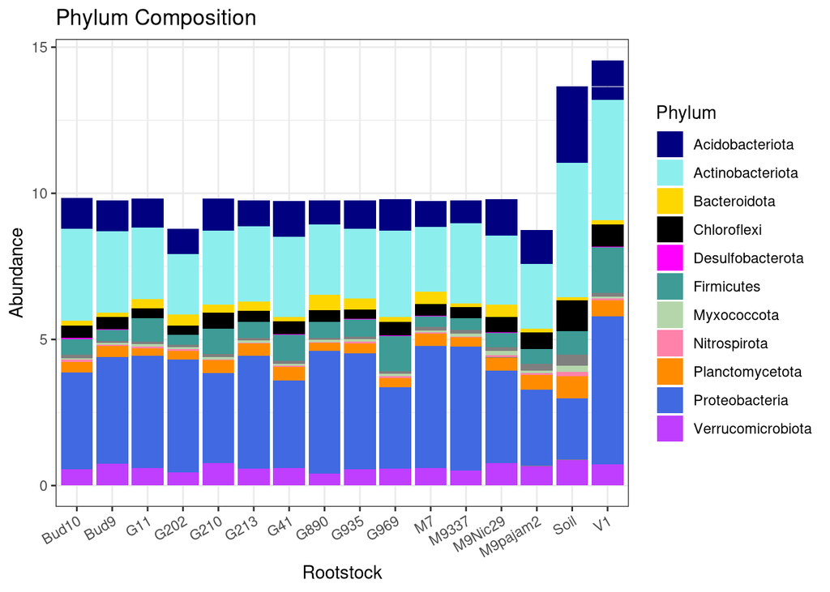

```r
  # fix the order of date (or other factors, but in this case I will leave them in alphabetical order, but comment out the code in case I decide to adapt it later.)
  #mutate(date = fct_relevel(date, c("6/2/21", "6/15/21", "10/5/21")),
         #rootstock= fct_relevel(rootstock, c("Copano West", "Copano East",
                                         # "Mesquite Bay", "Aransas Bay",
                                         # "Shipping Channel")))

# Stacked Bar Plot With All phyla
# Plot Phylum Abundances - make sure to load phylum_colors
phylum_df %>%
  # Warning: It's important to have one sample per x value,
  # otherwise, it will take the sum between multiple samples
  #dplyr::filter(depth == 0.0) %>%
  #dplyr::filter(fraction == "Whole") %>%
  ggplot(aes(x = Rootstock, y = Abundance, fill = Phylum)) +
  #facet_grid(.~date) +
  geom_bar(stat = "identity", color = "transparent") +
  labs(title = "Phylum Composition") +
  scale_fill_manual(values = phylum_colors) +
  theme_bw() +
  theme(axis.text.x = element_text(angle = 30, hjust = 1, vjust = 1))
```

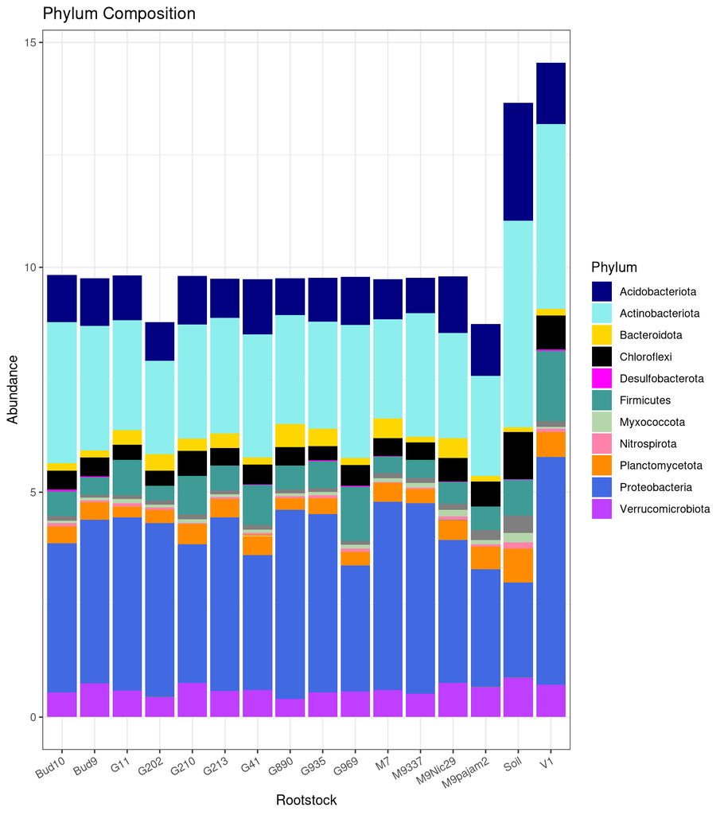

```r
## Make each phylum it's own row
phylum_df %>%
  # Warning: It's important to have one sample per x value,
  # otherwise, it will take the sum between multiple samples
  #dplyr::filter(depth == 0.0) %>%
  #dplyr::filter(fraction == "Whole") %>%
  ggplot(aes(x = Rootstock, y = Abundance, fill = Phylum)) +
  #facet_grid(Phylum~date, scale = "free") +
  geom_bar(stat = "identity", color = "transparent") +
  labs(title = "Phylum Composition") +
  scale_fill_manual(values = phylum_colors) +
  theme_bw() +
  theme(axis.text.x = element_text(angle = 30, hjust = 1, vjust = 1),
        strip.text.y = element_text(size = 5))
```

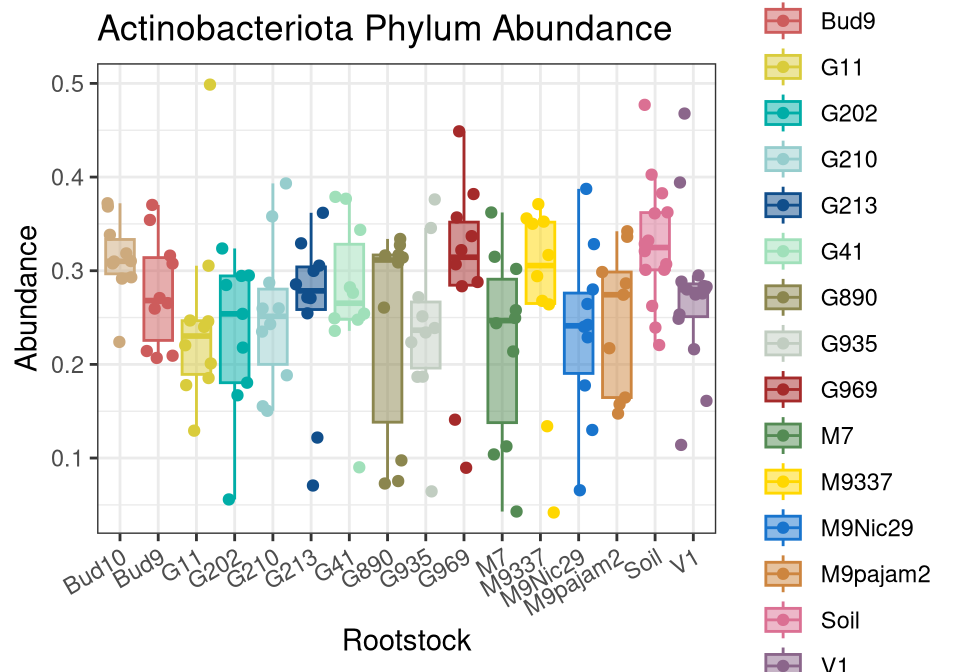

```r
# Narrow in on a specific group
# Actinobacteriota - y: abundance, x: station, dot plot + boxplot
phylum_df %>%
  dplyr::filter(Phylum == "Actinobacteriota") %>%
  # build the plot
  ggplot(aes(x = Rootstock, y = Abundance,
             fill = Rootstock, color = Rootstock)) +
  geom_boxplot(alpha = 0.5, outlier.shape = NA) + # outliers not plotted here in boxplot
  geom_jitter() +
  theme_bw() +
  labs(title = "Actinobacteriota Phylum Abundance") +
  scale_color_manual(values = Rootstock_colors) +
  scale_fill_manual(values = Rootstock_colors) +
    theme(axis.text.x = element_text(angle = 30, hjust = 1, vjust = 1),
          legend.position = "right") #+
```

```r
  #stat_compare_means(method = "kruskal.test", label.y =0.5) +
  #geom_pwc(method = "wilcox_test")
# Statistically: Kruskall-Wallis followed by a Wilcoxon-Mann-Whitney test
# These are non-parametric (non-normal) stat tests
```

## Family

```r
# Calculate the Family relative abundance
# Note: The read depth MUST be normalized in some way: scale_reads
family_df <-
  scaled_rooted_physeq %>%
  # agglomerate at the phylum level
  tax_glom(taxrank = "Family") %>%
  # Transform counts to relative abundance
  transform_sample_counts(function (x) {x/sum(x)}) %>%
  # Melt to a long format
  psmelt() %>%
  # Filter out Phyla that are <1% - get rid of low abundant Phyla
  dplyr::filter(Abundance > 0.01)
# Check family_df
str(family_df)
```

```
## 'data.frame':    4076 obs. of  22 variables:
##  $ OTU                : chr  "ASV_5" "ASV_1" "ASV_5" "ASV_5" ...
##  $ Sample             : chr  "M2_2022" "G34_2022" "G25_2022" "G31_2022" ...
##  $ Abundance          : num  0.813 0.719 0.666 0.572 0.496 ...
##  $ sample_Sample      : chr  "M2_2022" "G34_2022" "G25_2022" "G31_2022" ...
##  $ Rootstock          : chr  "M9337" "G969" "G890" "G969" ...
##  $ SeqSample          : chr  "M2" "G34" "G25" "G31" ...
##  $ TreeNumber         : chr  "74" "146" "203" "41" ...
##  $ YearSampled        : int  2022 2022 2022 2022 2022 2022 2022 2022 2022 2022 ...
##  $ SequencingRun      : int  1 1 1 1 1 1 1 1 2 1 ...
##  $ ARD                : chr  "susceptible" "resistant" "resistant" "resistant" ...
##  $ input              : num  52680 188583 232381 161591 200109 ...
##  $ filtered           : num  1817 117244 153884 106145 129910 ...
##  $ denoisedF          : num  1534 107780 145596 99700 121176 ...
##  $ denoisedR          : num  1499 109563 147686 101164 122129 ...
##  $ merged             : num  1078 66612 108007 72979 82874 ...
##  $ nochim             : num  752 51152 63025 44027 53243 ...
##  $ perc_reads_retained: num  1.43 27.12 27.12 27.25 26.61 ...
##  $ Kingdom            : chr  "Bacteria" "Bacteria" "Bacteria" "Bacteria" ...
##  $ Phylum             : chr  "Proteobacteria" "Firmicutes" "Proteobacteria" "Proteobacteria" ...
##  $ Class              : chr  "Gammaproteobacteria" "Clostridia" "Gammaproteobacteria" "Gammaproteobacteria" ...
##  $ Order              : chr  "Pseudomonadales" "Clostridiales" "Pseudomonadales" "Pseudomonadales" ...
##  $ Family             : chr  "Pseudomonadaceae" "Clostridiaceae" "Pseudomonadaceae" "Pseudomonadaceae" ...
```

[figure not shown]

```r
# Plot family
# Actinobacteriota Families
family_df %>%
  dplyr::filter(Phylum == "Actinobacteriota") %>%
  # build the plot
  ggplot(aes(x = Rootstock, y = Abundance,
             fill = Rootstock, color = Rootstock)) +
  facet_wrap(.~Family, scales = "free_y", nrow = 1) +
  geom_boxplot(alpha = 0.5, outlier.shape = NA) + # outliers not plotted here in boxplot
  geom_jitter() +
  theme_bw() +
  labs(title = "Actinobacteriota Family Abundance") +
  scale_color_manual(values = Rootstock_colors) +
  scale_fill_manual(values = Rootstock_colors) +
  theme(axis.text.x = element_text(angle = 30, hjust = 1, vjust = 1),
        legend.position = "bottom")
```

The family plot looks strange, I need to do more problem solving before moving on with the other taxonomic levels.